# Logistic Regression

July 2024

## Importing the data

We begin by loading the required packages:

```r
library(rstan)
library(HDInterval)
library(bayesplot)
library(ggplot2)
```

We now import the data files: after storing the path to the working directory (WD) in the `work_dir` object, we can set the WD and load the auxiliary functions:

```r
source("aux_functions.R")
```

## Data Preparation

Let us begin by considering a binary outcome variable `y` and two numeric regressors `x1` and `x2`:

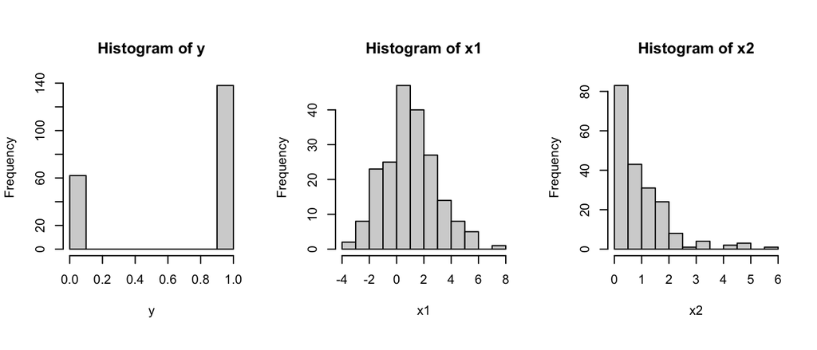

```r
par(mfrow=c(1,3), pty="s", oma=c(0,0,0,0))
hist(y)
hist(x1)
hist(x2)
```

```r
par(mfrow=c(1,1), pty="m")
```

Our goal is to estimate a logistic regression model:

$$y_i\sim \text{Bernoulli}(\pi_i)$$
where:

$$\pi_i=\frac{1}{1+\exp\lbrace\alpha+\beta_1x_{i,1}+\beta_2x_{i,2}\rbrace}$$
Therefore, we first need to set priors for $\alpha$, $\beta_1$ and $\beta_2$. Unlike linear regression models, however, choosing a distribution for these parameters through simulation checks is not as straightforward because of the non-linear transformation in the inverse-logistic function.

Moreover, whereas non-information or weak information is easy to conceptualized in linear models, how do these assumption translate in binary (or multinational) settings? Intuitively, uninformative or weakly informative priors would keep the chances of $y_i=1$ or $y_i=0$ roughly equal, which means $\pi_i\approx 0.5$.

To understand how priors on $\alpha$, $\beta_1$ and $\beta_2$ can be calibrated such that $\pi_i\approx 0.5$ across simulations, we begin by addressing what distribution best suits the intercept.

## Prior Calibaration

### Calibrating $\alpha$

Let us begin with four simple prior distributions for $\alpha$:

$$\begin{equation}
\begin{aligned}
& \alpha \sim N(0, 10)\\
& \alpha \sim N(0,2.5)\\
& \alpha \sim N(0,1.5)\\
& \alpha \sim N(0, 1)
\end{aligned}
\end{equation}$$

We simulate $S=1000$ draws from these distribution, compute $\pi^{s}=\frac{1}{1+\exp\lbrace\alpha^{s}\rbrace}$

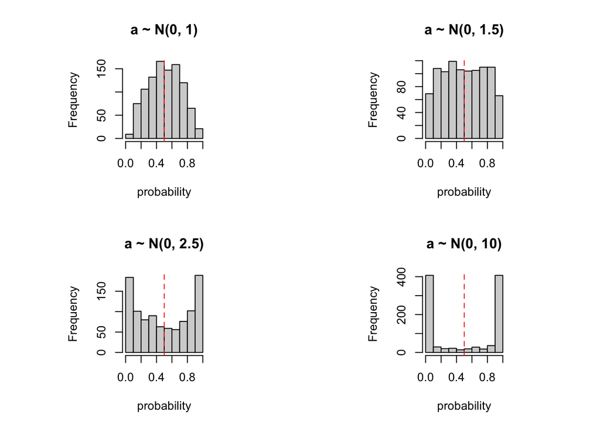

```r
par(mfrow=c(2,2), pty="s", oma=c(0,0,0,0))
for (j in c(1, 1.5, 2.5, 10)) {

  hist(boot::inv.logit(rnorm(1000, 0, j)),
       main = paste0("a ~ N(0, ", j, ")"),
       xlab = "probability")
  abline(v = 0.5, col = "red", lty = 2)

}
```

```r
par(mfrow=c(1,1), pty="m")
```

If we believe that $\pi\approx0.5$ is a reasonable assumption, then $\alpha\simN(0,1)$ is a good uninformative prior for the intercept. Notice how we would have never guessed that such a tight normal would have lead to a weakly informative prior.

### Calibrating the slope parameters $\beta_1$ and $\beta_2$

Understanding what prior to give $\beta_1$ and $\beta_2$ is a bit more complicated. In fact, not only do the distribution on these parameters will impact $\pi$, but also their interaction with the covariate values will play a major role.

To see how this plays out, we begin by simulating probabilities by first setting;

$$\begin{equation}
\begin{aligned}
& \alpha \sim N(0, 1) \\
& \beta_1 \sim N(0,5) \\
& \beta_2 \sim N(0,5)
\end{aligned}
\end{equation}$$

and computing $\pi_i^s=1/(1+\exp\lbrace\alpha^s+\beta^s_1x_{i,1}+\beta^s_2x_{i,2}\rbrace)$. Unlike our simulation for the sole intercept, here we adopt a slightly different visualization because we need to visualize $S\times N$ generated probabilities.

This time we use the `stan` program to simulate:

```r
dat_list <- list(
  N = length(y),
  x1 = x1,
  x2 = x2,
  y = y,
  mu_b1 = 0,
  mu_b2 = 0,
  sigma_b1 = 5,
  sigma_b2 = 5,
  mu_alpha = 0,
  sigma_alpha = 1
)

logi_reg <- stan_model("logistic_regression.stan")
logi_reg_prior <- stan_model("logistic_regression_prior.stan")

prior_sample <- sampling(logi_reg_prior,
                         data = dat_list,
                         algorithm = "Fixed_param")
prior_sample_fit <- extract(prior_sample)
```

Let us now visualize the simulated $\pi_i^s$:

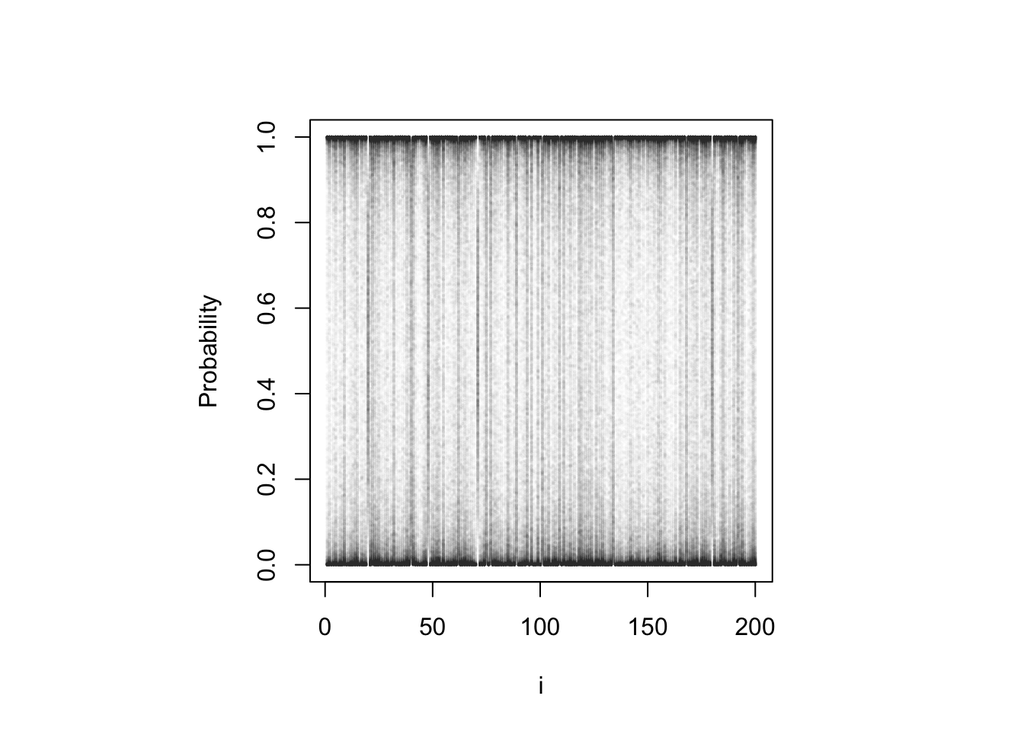

```r
plot_prior_point(prior_sample_fit$prob, xlab = "i", ylab = "Probability")
```

Notice how all the probability values concentrate around zero and one, while very few data points fall in the middle part of the plot. In other words, $\beta_1 \sim N(0,5)$ and $\beta_2 \sim N(0,5)$ are very informative in that they automatically set probability values to their extremes.

How can we go about this? We cloud try by setting thighter priors:

$$\begin{equation}
\begin{aligned}
& \alpha \sim N(0,1) \\
& \beta_1 \sim N(0,1) \\
& \beta_2 \sim N(0,1)
\end{aligned}
\end{equation}$$

```r
dat_list <- list(
  N = length(y),
  x1 = x1,
  x2 = x2,
  y = y,
  mu_b1 = 0,
  mu_b2 = 0,
  sigma_b1 = 1,
  sigma_b2 = 1,
  mu_alpha = 0,
  sigma_alpha = 1
)

prior_sample <- sampling(logi_reg_prior,
                         data = dat_list,
                         algorithm = "Fixed_param")
prior_sample_fit <- extract(prior_sample)
```

Let us now visualize the simulated $\pi_i^s$:

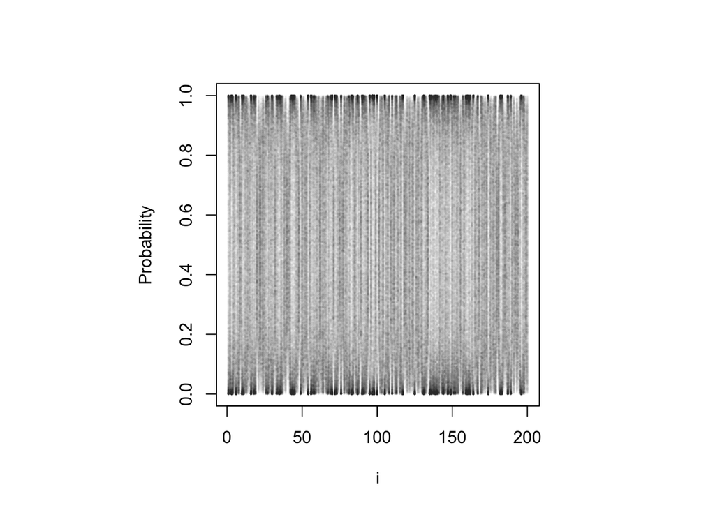

```r
plot_prior_point(prior_sample_fit$prob, xlab = "i", ylab = "Probability")
```

This looks slightly better, but many probabilities still lie in the 0,1 area (black areas around the edges). Moreover, these prior settings are conditional on the distribution of $x_1$ and $x_2$, meaning that different configuration of these variables might invalidate the results displayed above. For example, let us repeat this exercise with two covariates with larger support:

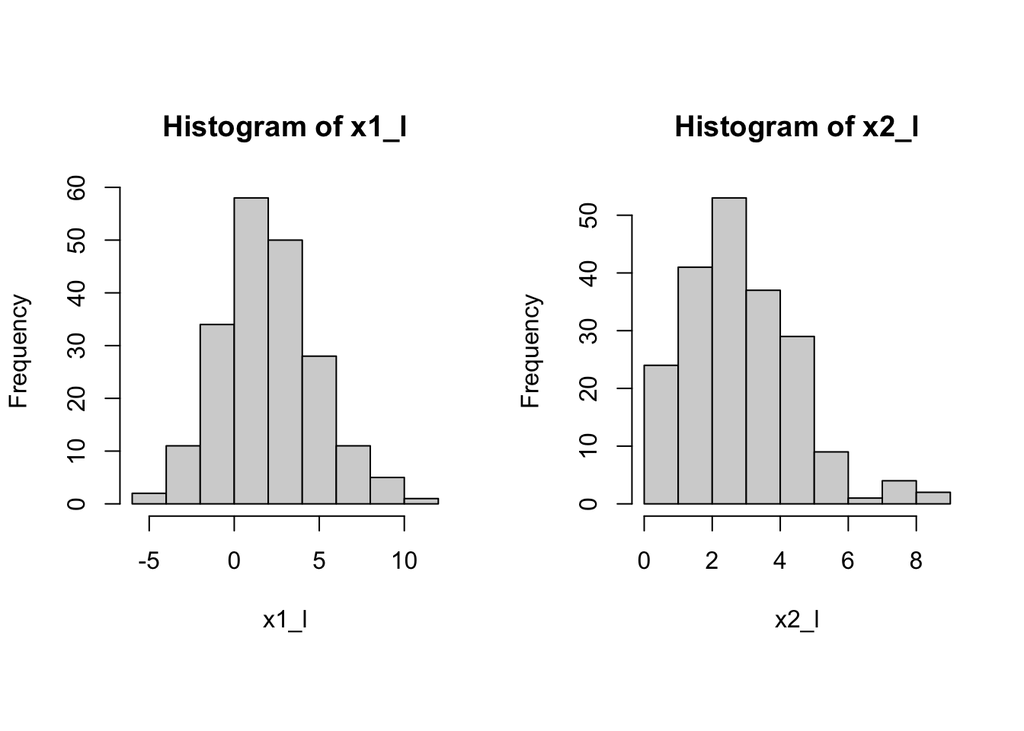

```r
set.seed(123)
x1_l <- rnorm(200, 2, 3)
x2_l <- rgamma(200, 3, 1)

par(mfrow=c(1,2), pty="s", oma=c(0,0,0,0))
hist(x1_l)
hist(x2_l)
```

```r
par(mfrow=c(1,1), pty="m")

dat_list_l <- list(
  N = length(y),
  x1 = x1_l,
  x2 = x2_l,
  y = y,
  mu_b1 = 0,
  mu_b2 = 0,
  sigma_b1 = 1,
  sigma_b2 = 1,
  mu_alpha = 0,
  sigma_alpha = 1
)

prior_sample_l <- sampling(logi_reg_prior,
                           data = dat_list_l,
                           algorithm = "Fixed_param")
```

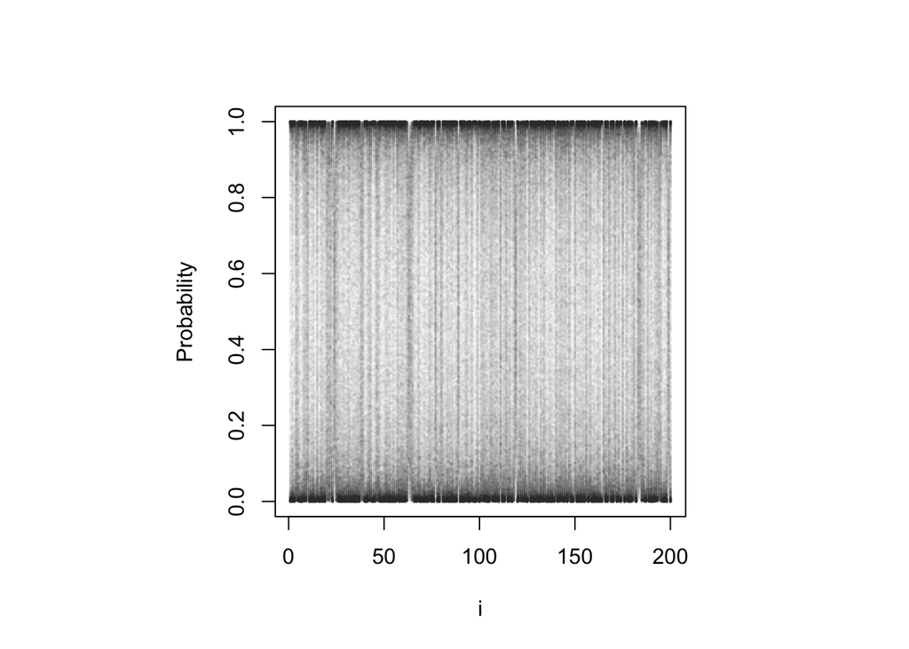

```r
prior_sample_fit_l <- extract(prior_sample_l)

plot_prior_point(prior_sample_fit_l$prob, xlab = "i", ylab = "Probability")
```

Even with the a tightener distribution on $\beta_1$ and $\beta_2$ we are back to the original problem.

### The importance of scaling

To make the scale of $x_1$ and $x_2$ irrelevant when placing priors on $\beta_1$ and $\beta_2$, one can *scale* the regressors to have mean zero and standard deviation 0.5, i.e.,

$$x_{i,p}^{sc}=\frac{x_{i,p}-\bar{x}_{p}}{sd(x_{p})}\times
0.5$$

Let us begin by scaling the initial covariates and simulate probability values:

```r
x1_sc <- as.vector(scale(x1)*0.5)
x2_sc <- as.vector(scale(x2)*0.5)

dat_list <- list(
  N = length(y),
  x1 = x1_sc,
  x2 = x2_sc,
  y = y,
  mu_b1 = 0,
  mu_b2 = 0,
  sigma_b1 = 1,
  sigma_b2 = 1,
  mu_alpha = 0,
  sigma_alpha = 1
)

prior_sample <- sampling(logi_reg_prior,
                         data = dat_list,
                         algorithm = "Fixed_param")
prior_sample_fit <- extract(prior_sample)
```

We next repeat the exercise using scaled values for `x1_l` and `x2_l`:

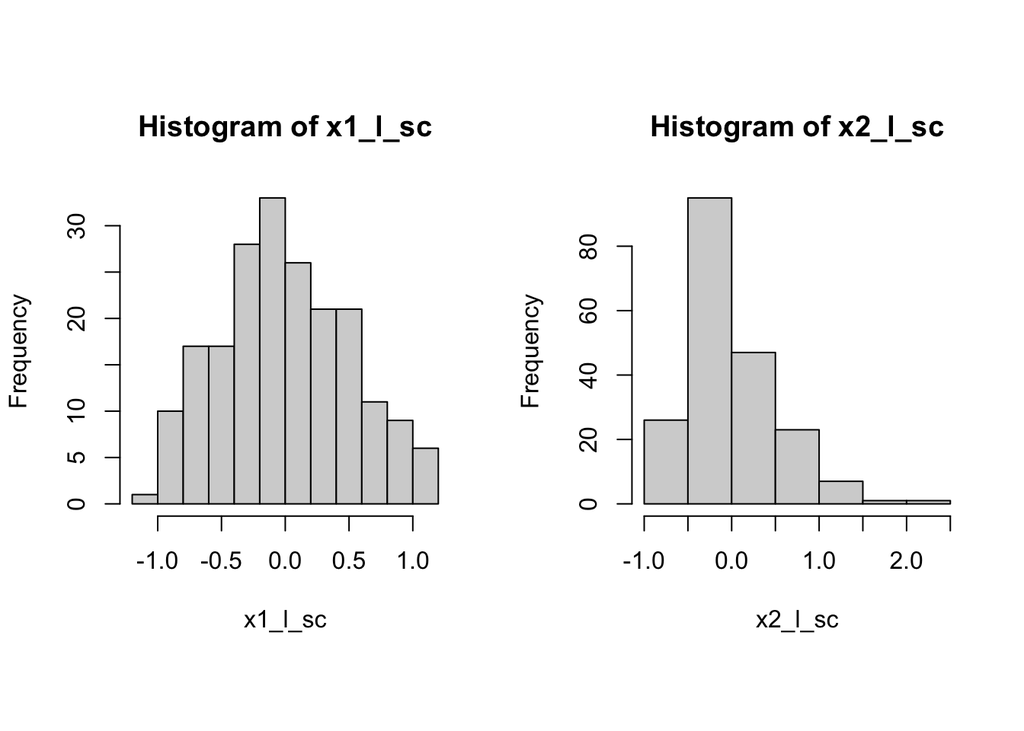

```r
x1_l_sc <- as.vector(scale(rnorm(200, 2, 3))*0.5)
x2_l_sc <- as.vector(scale(rgamma(200, 3, 1))*0.5)

par(mfrow=c(1,2), pty="s", oma=c(0,0,0,0))
hist(x1_l_sc)
hist(x2_l_sc)
```

```r
par(mfrow=c(1,1), pty="m")

dat_list_l <- list(
  N = length(y),
  x1 = x1_l_sc,
  x2 = x2_l_sc,
  y = y,
  mu_b1 = 0,
  mu_b2 = 0,
  sigma_b1 = 1,
  sigma_b2 = 1,
  mu_alpha = 0,
  sigma_alpha = 1
)

prior_sample_l <- sampling(logi_reg_prior,
                           data = dat_list_l,
                           algorithm = "Fixed_param")
prior_sample_fit_l <- extract(prior_sample_l)
```

We can finally visualize the simulated $\pi_i$ for both configurations:

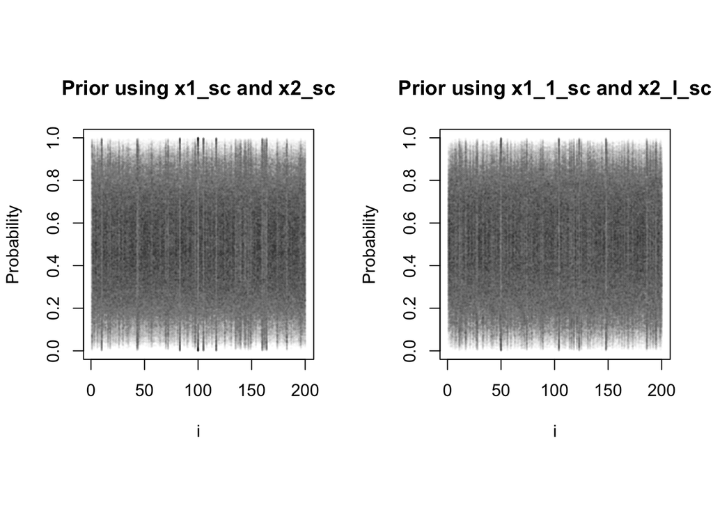

```r
par(mfrow=c(1,2), pty="s")
plot_prior_point(prior_sample_fit$prob, xlab = "i", ylab = "Probability",
                 main = "Prior using x1_sc and x2_sc")
plot_prior_point(prior_sample_fit_l$prob, xlab = "i", ylab = "Probability",
                 main = "Prior using x1_1_sc and x2_l_sc")
```

```r
par(mfrow=c(1,1), pty="m")
```

The prior distribution of $\pi_i$ now concentrates around values close to 0.5, as intended, regardless of the covariates’ support.

## Estimation

Now that we have figured out a reasonable weakly informative prior configuration for $\alpha$, $\beta_1$ and $\beta_2$, we can fit the model using HMC:

```r
fit_sample <- sampling(logi_reg,
                       data = dat_list,
                       chains = 4,
                       cores = 4)
sample_fit <- extract(fit_sample)
```

Since $x_1$ and $x_2$ have been scaled, we need to map the estimated coefficients back to the original scale of the data:

```r
alpha <- sample_fit$alpha - (sample_fit$beta1 * (mean(x1)*0.5)/sd(x1)) - (sample_fit$beta2 * (mean(x2)*0.5)/sd(x2))
beta1 <- sample_fit$beta1 * (0.5/sd(x1))
beta2 <- sample_fit$beta2 * (0.5/sd(x2))
```

Now we can visualize their marginal posterior:

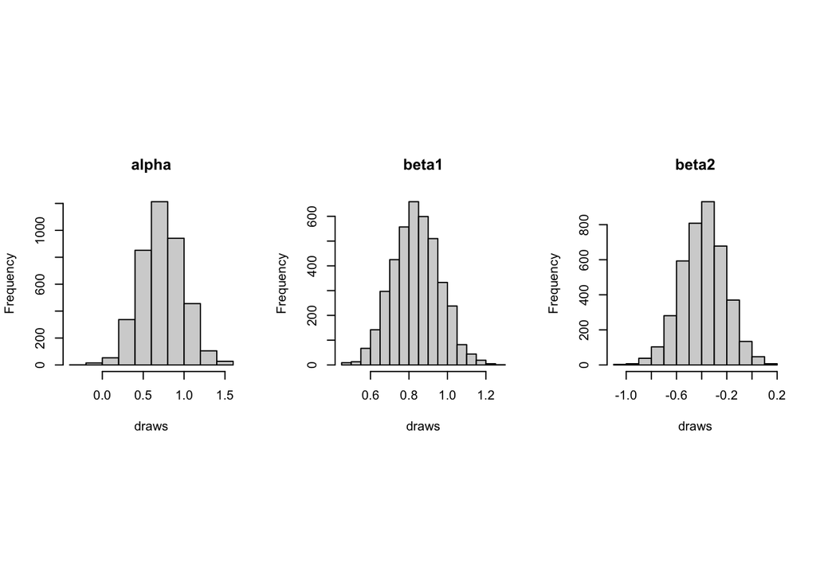

```r
par(mfrow=c(1,3), pty="s")
hist(alpha, main = "alpha", xlab = "draws")
hist(beta1, main = "beta1", xlab = "draws")
hist(beta2, main = "beta2", xlab = "draws")
```

```r
par(mfrow=c(1,1), pty="m")
```

And check model fit through the posterior predictive distribution. First, let’s have a look at the posterior predicted probabilities:

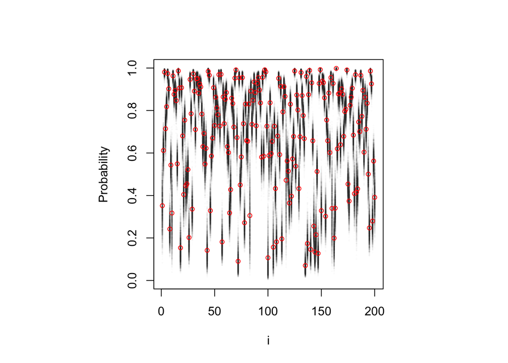

```r
plot_prior_point(sample_fit$prob, xlab = "i", ylab = "Probability")
points(colMeans(sample_fit$prob), col = "red", cex=.75)
```

Next, we compute the correct classification rate (CCR) for each posterior sample $\tilde{y}^s$ and visualize the distribution of the CCR for each $s\in1,\ldots,S$:

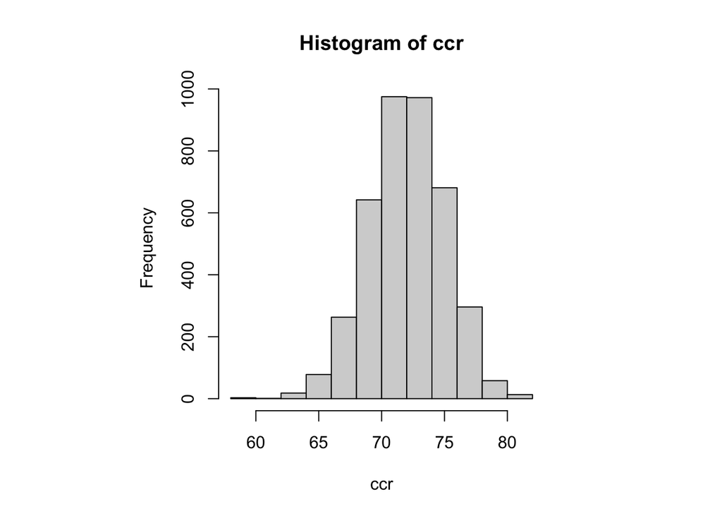

```r
ccr <- numeric(length = nrow(sample_fit$y_pred))
for(s in 1:nrow(sample_fit$y_pred)) {

  ccr[s] <- sum(diag(table(sample_fit$y_pred[s,], y)))/sum(table(sample_fit$y_pred[s,], y))*100

}

par(pty="s")
hist(ccr)
```

```r
par(pty="m")
```